# S&P 500

## Dependencies:

```
- sklearn
- pandas
- numpy
- keras
- python-highcharts
- sqlalchemy
- matplotlib
- xgboost
- IPython
```

## Installation of misc modules

```python
!pip install python-highcharts
!pip install sqlalchemy
!pip install psycopg2
```

## Import Modules:

```python
#Necessary modules for algorithms

import datetime
#pandas for data preprocessing
import pandas as pd

#packages for ML and DL
from sklearn.preprocessing import MinMaxScaler
from keras.models import Sequential
from keras.layers import LSTM, Dense, Dropout, GRU, Merge, Flatten
from keras import optimizers
from keras import regularizers
import keras.backend as K

#ML math function Library
import numpy as np

#modules for plotting
import matplotlib.pyplot as plt
from matplotlib import style
style.use('ggplot')

#Xgboost module
from xgboost.sklearn import XGBRegressor
import scipy.stats as st
from sklearn.model_selection import GridSearchCV

#For interactive visualisation
from highcharts import Highstock
from highcharts.highstock.highstock_helper import jsonp_loader
from highcharts import Highchart
```

```python
#Extra piece for plotting lots of data points
import matplotlib as mpl
import seaborn as sns

#chunk-size is random number that can fit the whole dataset
mpl.rcParams['agg.path.chunksize'] = 100000


#Importing HTML to view the highcharts
from IPython.core.display import HTML

import warnings
warnings.filterwarnings("ignore", category=DeprecationWarning)
warnings.simplefilter('ignore')

#Calling the metrics fucntions to test model accuracy and reliability
from sklearn.metrics import mean_squared_error, recall_score, precision_score, mean_absolute_error, explained_variance_score, r2_score
```

#### Getting the SPY data

```python
import sqlalchemy
engine = sqlalchemy.create_engine('postgresql://tino_analyst:tino_analyst122@174.138.55.209:54432/tino_predictions')
df = pd.read_sql_query("SELECT * FROM historical_data where symbol=\'SPY\';", engine)
```

## Data Preprocessing:

### Steps:

- Sorting it into ascending order of date
- Getting rid of useless features like 'symbol', 'name', 'class'
- Making numpy array of lead values, that will be predicted.
- Scaling the numpy arrays into a feature vector between [0,1] to make them generalised.
- Droping the lead values from the dataframe to be processed.

```python
#Data pre-processing

df.sort_values('date_txn', inplace=True)
#df = df[800:]
df.drop(['symbol', 'name', 'class_type_of'], axis=1, inplace=True)
df.date_txn = pd.to_datetime(df.date_txn)
df.index = df['date_txn']
df.drop('date_txn', axis=1, inplace=True)
df.replace(np.nan, 0, inplace=True)
```

```python
#Getting the lead values and getting numpy array
lead_5 = np.array(df['lead_5'])#the target
lead_10 = np.array(df['lead_10'])
lead_1 = np.array(df['lead_1'])
```

```python
#SKlearn scaler function, i.e scale between 0 and 1
scaler = MinMaxScaler()
```

```python
#Sclaing the lead values
lead_5_scaled = scaler.fit_transform(lead_5.reshape(-1,1)) #scale for sequential data
lead_10_scaled = scaler.fit_transform(lead_10.reshape(-1,1))
lead_1_scaled = scaler.fit_transform(lead_1.reshape(-1,1))
```

```python
# dropping the lead values
d = df.drop(['lead_10', 'lead_5', 'lead_1'], axis=1)
values = d.values
scaled = scaler.fit_transform(values)
```

## Model Execution and Training:

Executing algorithms and helper methods

### Methods:

##### - train(args**):

```
Takes in lead scaled and all values to provide train and test features
```

##### - StackLSTM(class-args**):

```
The essential LSTM wrapper function of Keras LSTM algorithm.
```

##### - StackGRU(class-args**):

```
The GRU wrapper function of keras GRU algorithm.
```

##### - denormalize(s, max, min):

```
The method to take in scled inputs and maxx and min value to return the original input.
```

##### - get_results(args**):

```
The method to get the predicted results from different algorithms
```

##### - outliers(tmp):

```
The method to calculate outliers for anomaly detection.
```

##### - model_uncertainity(args**):

```
The method to get uncertainty quantification using MC dropout and Yarin Gal's Paper.
```

##### - start_driver(args**):

```
The main driver function to get everything running.
```

```python
def train(lead_scaled, values, scaled):
  '''
  Method to get train_X, test_X and train_y and test_y values.
  :param lead_scaled: numpy array of scaled values
  :param values: values of the datafram in raw form
  :param scaled: scaled form of values

  :return: train_X, test_X, train_y, test_y, xgbtrain_X, xgbtest_X
  - train and test samples
  - xgbtrain and xgbtest are specifically for xgboost
  '''
  #prepare for training algorithm
  n_train_hours = int(values.shape[0]*0.75)
  train = scaled[:n_train_hours, :]
  test = scaled[n_train_hours:, :]

  train_X, train_y = train, lead_scaled[:n_train_hours]
  test_X, test_y = test, lead_scaled[n_train_hours:]

  xgbtrain_X = train_X
  xgbtest_X = test_X
  # reshape input to be 3D [samples, timesteps, features]
  train_X = train_X.reshape((train_X.shape[0], 1, train_X.shape[1]))
  test_X = test_X.reshape((test_X.shape[0], 1, test_X.shape[1]))

  return train_X, test_X, train_y, test_y, xgbtrain_X, xgbtest_X
```

#### LSTM class

Reason to choose LSTM :

- LSTM’s are pretty good at extracting patterns in input feature space, where the input data spans over long sequences. Given the gated architecture of LSTM’s that has this ability to manipulate its memory state, they are ideal for such problems.
- This adds a great benefit in time series forecasting, where classical linear methods can be difficult to adapt to multivariate or multiple input forecasting problems
- Flexibility to use several combinations of seq2seq LSTM models to forecast time-series

```python
class StackLSTM():
    '''
    LSTM wrapper class
    '''

    model = None

    def __init__(self, length, numAttr, neurons, dropouts, activations):
        '''
        Method to assign variables when the class is called.
        :param length:  length of the input array - part of the definition of the first layer shape
        :param numAttr: number of attributes - second part of the definition of the first layer shape
        :param neurons: array of integers defining the number of neurons in each layer and the number of layers (by the length of the array) - Do not include the final layer
        :param dropouts: array of doubles (0 - 1) of length neurons - 1 defining the dropout at each level - do not include the final layer
        :param activations: array of strings of length neurons to define the activation of each layer - do not include the final layer
        '''
        self.length = length
        self.numAttr = numAttr
        self.neurons = neurons
        self.dropouts = dropouts
        self.activations = activations

        ###Check to see if the length of arrays are appropriate
        if len(neurons) != len(dropouts) + 1:
            print('The length of the dropouts array must be one less than the length of the neurons array')
            raise ValueError
        if len(neurons) != len(activations):
            print('The length of the activations array must be the same as the length of the neurons array')
            raise ValueError


    def buildModel(self):
        '''
        Method to build the model based on the inputs when the class is instantiated.
        :return:
        '''
        self.model = Sequential()
        self.model.add(LSTM(self.neurons[0],return_sequences=True, activation=self.activations[0], input_shape=(self.length,self.numAttr)))
        self.model.add(Dropout(self.dropouts[0]))
        for i in np.arange(start = 1, stop = len(self.neurons)):
            self.model.add(LSTM(self.neurons[i], return_sequences=True, activation = self.activations[i]))
            self.model.add(Dropout(self.dropouts[i-1]))

        ###Add the final layer
        self.model.add(LSTM(self.neurons[len(self.neurons)-1],return_sequences=True, activation = self.activations[len(self.activations)-1]))
        self.model.add(Flatten())
        self.model.add(Dense(1, activation='linear',))
        pass


    def compileModel(self, loss='mse', optimizer='adam', metrics=['accuracy']):
        '''
        Method to compile the model using the parameters given by the inputs to the method
        :param loss: the loss functions to use in the compilation
        :param optimizer: the optimizer to use in the compilation
        :param metrics: list of metrics to use in the compilation
        :param shuffle: boolean to shuffle values in fitting
        :return:
        '''
        self.model.compile(loss=loss, optimizer=optimizer, metrics=metrics)
        pass


    def fitModel(self, x, y, epochs, batchSize,validation_data, verbose=0):
        '''
        Method to fit the model to data provided
        :param xtrain: inputs to train on
        :param ytrain: outputs to train on
        :param epochs: number of epochs to train the model
        :param batchSize: size of batches on which to train the model
        :param verbose: boolean (0, 1) value to control the verbosity of the fitting
        :return:
        '''
        m = self.model.fit(x, y, nb_epoch=epochs, batch_size=batchSize, verbose=verbose,validation_data=validation_data)
        return m


    def predict(self, x):
        '''
        Method to provide predictions from the model
        :param x: values on which to predict
        :return: predicted values
        '''
        y = self.model.predict(x)
        return y

    def getParams(self):
        '''
        Method to return the parameters of the model
        :return:
        '''
        return self.model.get_config()

    def get_model(self):
        '''
        Method to return the model
        '''
        return self.model
```

#### GRU class

Reason to choose GRU:

- The GRU unit controls the flow of information like the LSTM unit, but without having to use a memory unit. It just exposes the full hidden content without any control
- The performance is on par with LSTM, but computationally more efficient
- LSTMs should in theory remember longer sequences than GRUs and outperform them in tasks requiring modeling long-distance relations
- GRU is better than LSTM as it is easy to modify and doesn't need memory units, therefore, faster to train than LSTM and give as per performance

```python
class StackGRU():
    '''
    GRU wrapper class
    '''

    model = None

    def __init__(self, length, numAttr, neurons, dropouts, activations):
        '''
        Method to assign variables when the class is called.
        :param length:  length of the input array - part of the definition of the first layer shape
        :param numAttr: number of attributes - second part of the definition of the first layer shape
        :param neurons: array of integers defining the number of neurons in each layer and the number of layers (by the length of the array) - Do not include the final layer
        :param dropouts: array of doubles (0 - 1) of length neurons - 1 defining the dropout at each level - do not include the final layer
        :param activations: array of strings of length neurons to define the activation of each layer - do not include the final layer
        '''
        self.length = length
        self.numAttr = numAttr
        self.neurons = neurons
        self.dropouts = dropouts
        self.activations = activations

        ###Check to see if the length of arrays are appropriate
        if len(neurons) != len(dropouts) + 1:
            print('The length of the dropouts array must be one less than the length of the neurons array')
            raise ValueError
        if len(neurons) != len(activations):
            print('The length of the activations array must be the same as the length of the neurons array')
            raise ValueError


    def buildModel(self):
        '''
        Method to build the model based on the inputs when the class is instantiated.
        :return:
        '''
        self.model = Sequential()
        self.model.add(GRU(self.neurons[0],return_sequences=True, activation=self.activations[0], input_shape=(self.length,self.numAttr)))
        self.model.add(Dropout(self.dropouts[0]))
        for i in np.arange(start = 1, stop = len(self.neurons)):
            self.model.add(GRU(self.neurons[i], return_sequences=True, activation = self.activations[i]))
            self.model.add(Dropout(self.dropouts[i-1]))

        ###Add the final layer
        self.model.add(GRU(self.neurons[len(self.neurons)-1],return_sequences=True, activation = self.activations[len(self.activations)-1]))
        self.model.add(Flatten())
        self.model.add(Dense(1, activation='linear',))
        pass


    def compileModel(self, loss='mse', optimizer='adam', metrics=['accuracy']):
        '''
        Method to compile the model using the parameters given by the inputs to the method
        :param loss: the loss functions to use in the compilation
        :param optimizer: the optimizer to use in the compilation
        :param metrics: list of metrics to use in the compilation
        :param shuffle: boolean to shuffle values in fitting
        :return:
        '''
        self.model.compile(loss=loss, optimizer=optimizer, metrics=metrics)
        pass


    def fitModel(self, x, y, epochs, batchSize,validation_data, verbose=0):
        '''
        Method to fit the model to data provided
        :param xtrain: inputs to train on
        :param ytrain: outputs to train on
        :param epochs: number of epochs to train the model
        :param batchSize: size of batches on which to train the model
        :param verbose: boolean (0, 1) value to control the verbosity of the fitting
        :return:
        '''
        m = self.model.fit(x, y, nb_epoch=epochs, batch_size=batchSize, verbose=verbose,validation_data=validation_data)
        return m


    def predict(self, x):
        '''
        Method to provide predictions from the model
        :param x: values on which to predict
        :return: predicted values
        '''
        y = self.model.predict(x)
        return y

    def getParams(self):
        '''
        Method to return the parameters of the model
        :return:
        '''
        return self.model.get_config()

    def get_model(self):
        '''
        Method to return the model
        '''
        return self.model
```

##### Denormalise

denormalisation is needed to get the before prediction result and compare with predictions

```python
def denormalize(s,max,min):
    """
    Get the denormalised numbers from reshaped np.array
    :param s: dataframe or list type or a number
    :param max: max value within the list or dataset
    :param min: min value within the list or dataset

    :returns : s*(max-min)+min, value
    """
    return s*(max - min) + min
```

##### Get_results

Trains values for algorithms and predicts, finds rmse and sends to driver function.

```python
def get_results(values, model, lead, train_X, test_X, train_y, test_y, xgbtrain_X=0, xgbtest_X=0, is_xgb=False):
    '''
    This method takes in input model and values and outputs the result dataframe and rmse scores.
    :param values: raw values of dataframe
    :param model: model name, i.e if lstm, gru or xgboost
    :param train_X, train_y: training parameters
    :param test_X, test_y: test parameters
    :xgbtrain_X: default = 0, the training sample for xgboost
    :xgbtest_X: default = 0, the test sample for xgboost
    :param is_xgb: boolean, deafult=False, True if xgboost is needed.

    :return: rmse, result
    :param rmse: float, rmse value
    :param resultdf: datframe with actual and predicted values
    '''

    #max and minimum closing price
    lead_1_min = min(lead)
    lead_1_max = max(lead)
    n_train_hours = int(values.shape[0]*0.75)
    train2 = values[:n_train_hours, :]
    test2 = values[n_train_hours:, :]
    train_yd = lead[:n_train_hours]
    test_yd = lead[n_train_hours:]
    """
    Get denormalised results for models : LSTM, GRU, xgboost
    :param model: model name or object
    :param is_xb: boolean, if model=xgboost: is_xgb=True

    :return: rmse(num, float) and result dataframe(pandas dataframe)
    """
    if is_xgb:
        yhat = model.predict(xgbtest_X)
        ythat = model.predict(xgbtrain_X)
    else:
        yhat = model.predict(test_X)
        ythat = model.predict(train_X)
        #print(yhat)
    yhat_d = denormalize(yhat, lead_1_max,lead_1_min)
    ythat_d = denormalize(ythat,lead_1_max,lead_1_min)
    #print(yhat_d)

    results = {'actual': np.append(train_yd,test_yd),
               'predicted':np.append(ythat_d,yhat_d)}
    #print(results)
    resultdf = pd.DataFrame(results,index=d.index)
    rmse = np.sqrt(mean_squared_error(test_yd, yhat_d))
    return rmse, resultdf
```

#### Anomaly Detection

Getting anomaly points for prediction.

```python
def outliers(tmp):
    """
    Get the outliers
    :param tmp: list

    :return outs: list of outliers
    """
    outs = []
    mean = sum(tmp)/(1.0*len(tmp))
    var = sum((tmp[i] - mean)**2 for i in range(0, len(tmp)))/(1.0*len(tmp))
    std = var**0.5
    outs = [tmp[i] for i in range(0, len(tmp)) if abs(tmp[i]-mean) > 1.96*std]
    return outs

#data for anomaly prediction
```

### Model Uncertainity

- Getting uncertainity in any model.
- Theory:

  ```
    p(yi|xi,Xtrain,Ytrain)=∫p(yi|xi,ω)
    p(ω|Xtrain,Ytrain)
    dω≈∫p(yi|xi,ω)qθ(ω)dω
    =:qθ(yi|xi)
  ```

  we have that yi is a draw from an approximation to the predictive distribution.
- This process is equivalent to drawing a new function for each test point, which results in extremely erratic depictions that have peaks at different locations
- Drawing a new function for each test point makes no difference if all we care about is obtaining the predictive mean and predictive variance, but this process does not result in draws from the induced distribution over functions
- [Yarin Gal's PhD thesis describing this process](http://mlg.eng.cam.ac.uk/yarin/blog_2248.html)

```python
def model_uncertainity2(model, x_test, y_test, B, confidence):
    '''
    :param model: model class object; lstm or gru
    :x_test: array, test X sample
    :y_test: array, test y sample
    :B: int, beta factor for number of iterations for Monte Carlo
    :confidence: percent;int , percent factor of uncertainity
    '''

    MC_output = K.function([model.layers[0].input, K.learning_phase()], [model.layers[-1].output])
    learning_phase = True  # use dropout at test time

    MC_samples = [MC_output([x_test, learning_phase])[0] for _ in range(B)]
    MC_samples = np.array(MC_samples)

    eta1 = np.mean(MC_samples - (np.mean(MC_samples)**2))#model misspecification and model uncertainity
    eta2 = mean_squared_error(model.predict(x_test), y_test) #inherent noise
    model_uncer = np.sqrt(eta1**2 + eta2**2)

    Merror = (st.norm.ppf((1+(confidence/100))/2))*model_uncer

    return Merror
```

```python
def model_reliability(res0, res1, m):
  '''
  This method takes in result matrices and outputs score dataframe
  :param res0: result matrix, columns=['actual'['predicted']]
  :param res1: result matrix, columns=['actual'['predicted']]
  :param m: ensemble matrix, columns=['actual']

  :return: score, dataframe
  '''
  #lstm
  mae0 = mean_absolute_error(res0['predicted'], res0['actual'])
  mse0 = mean_squared_error(res0['predicted'], res0['actual'])
  rmse0 = np.sqrt(mse0)
  r20 = r2_score(res0['predicted'], res0['actual'])
  evs0 = explained_variance_score(res0['predicted'], res0['actual'])

  #gru
  mae1 = mean_absolute_error(res1['predicted'], res0['actual'])
  mse1 = mean_squared_error(res1['predicted'], res0['actual'])
  rmse1 = np.sqrt(mse1)
  r21 = r2_score(res1['predicted'], res0['actual'])
  evs1 = explained_variance_score(res1['predicted'], res0['actual'])

  #ensembled
  mae3 = mean_absolute_error(m, res0['actual'])
  mse3 = mean_squared_error(m, res0['actual'])
  rmse3 = np.sqrt(mse3)
  r23 = r2_score(m, res0['actual'])
  evs3 = explained_variance_score(m, res0['actual'])

  score_frame = pd.DataFrame(index=['mae', 'rmse', 'r2', 'EVR'])

  score_frame['LSTM'] = [mae0, rmse0, r20, evs0]
  score_frame['GRU'] = [mae1, rmse1, r21, evs1]
  score_frame['Ensemble'] = [mae3, rmse3, r23, evs3]

  return score_frame
```

### Driver Function

- Calls the helper fuction
- Initialies the classes
- Builds models
- Calls Anomaly fucntion and plots outliers
- Calls plot functions
- Ensembles LSTM and GRU models.
  - Soft Voting.
  - Specific weights can be assigned to each classifier via the weights parameter. When weights are provided, the predicted class probabilities for each classifier are collected, multiplied by the classifier weight, and averaged. The final class label is then derived from the class label with the highest average probability.

```python
def start_driver(name, lead, lead_scaled, values, scaled, epochs_=1000,
                 batchsize=64,
                 neurons = [128, 128, 128, 128],
                 dropouts = [0.2, 0.2, 0.2],
                 activations = ['relu', 'relu', 'relu', 'relu']):

  train_X, test_X, train_y, test_y, xgbtrain_X, xgbtest_X = train(lead_scaled, values, scaled)

  #hyper-parameters

  length = train_X.shape[1]
  numAttr = train_X.shape[2]



  print('start LSTM...length : {}|| num of attributes : {}|| neurons : {}|| dropouts : {}|| activation : {}|| epochs:{}|| batch size : {}'.format(length, numAttr, neurons, dropouts, activations, epochs_, batchsize))

  lstm = StackLSTM(length, numAttr, neurons, dropouts, activations) #lstm class object

  lstm.buildModel()
  lstm.compileModel()
  history0 = lstm.fitModel(train_X, train_y, epochs=epochs_, batchSize=batchsize, validation_data=(test_X, test_y), verbose=0)

  print('start GRU...length : {}|| num of attributes : {}|| neurons : {}|| dropouts : {}|| activation : {}|| epochs:{}|| batch size : {}'.format(length, numAttr, neurons, dropouts, activations, epochs_, batchsize))

  gru = StackGRU(length, numAttr, neurons, dropouts, activations) #gru class object


  gru.buildModel()
  gru.compileModel()
  history1 = gru.fitModel(train_X, train_y, epochs=epochs_, batchSize=batchsize, validation_data=(test_X, test_y), verbose=0)

  %matplotlib inline


  plt.figure(figsize=(10,10))
  plt.subplot(211)
  plt.plot(history0.history['loss'], label='train')
  plt.plot(history0.history['val_loss'], label='test')
  plt.legend()
  plt.title('LSTM')
  plt.subplot(212)
  plt.plot(history1.history['loss'], label='train')
  plt.plot(history1.history['val_loss'], label='test')
  plt.legend()
  plt.title('GRU')

  plt.show()

  '''
  print('start XGBoost...')
  #hyper parameters for xgboost
  params = {
      'max_depth': [5,10,15],
      'n_estimators': [50,100,150]
  }

  xr = XGBRegressor()

  gs = GridSearchCV(xr, params, n_jobs=1,verbose=1)
  gs.fit(xgbtrain_X, train_y)
  print(gs.best_params_ )
  '''


  rmse0, res0 = get_results(values,lstm,lead, train_X, test_X, train_y, test_y)
  rmse1, res1 = get_results(values, gru,lead,  train_X, test_X, train_y, test_y)
  #rmse2, res2 = get_results(values, gs,lead,  train_X, test_X, train_y, test_y, xgbtrain_X=xgbtrain_X, xgbtest_X=xgbtest_X, is_xgb=True)




  plt.figure(figsize=(20,6))
  plt.title('LEAD')
  plt.plot(df.index,res0['actual'],label='actual',c='red' )
  plt.plot(res0.index,res0['predicted'],label='LSTM predicted', c='blue')
  plt.plot(res0.index,res1['predicted'],label='GRU predicted', c='green')
  #plt.plot(res0.index,res2['predicted'],label='xgBoost Regressor', c='magenta')
  axvline = str(res0.index[train_X.shape[0]])
  plt.axvline(x = axvline,ls='--',lw=2,c='k',label='Train-Test Boundary')
  plt.legend()

  print("LSTM RMSE: {}".format(rmse0))
  print("GRU RMSE: {}".format(rmse1))
  #print("xgBoost Regressor: {}".format(rmse2))
  plt.show()

  if rmse0 <= rmse1: #and rmse0 <= rmse2:
      n0 = 0.55
      n1 = 0.45
      #n2 = 0.3
  elif rmse1 <= rmse0:# and rmse1 <= rmse2:
      n0 = 0.45
      n1 = 0.55
      #n2 = 0.3
  #else:
  #    n0 = 0.3
  #    n1 = 0.3
  #    n2 = 0.4

  m = res0['predicted']*n0 + res1['predicted']*n1 #+res2['predicted']*n2
  print(mean_squared_error(res0['actual'], m))


  ensemble_results = {'actual': res0['actual'],
                 'predicted':m}
  ensemble_resultdf = pd.DataFrame(ensemble_results,index=d.index)

  score_frame = model_reliability(res0, res1, m)



  lst1 = list(df[name])
  out1 = outliers(lst1)
  lst2 = list(ensemble_resultdf['predicted'])
  out2 = outliers(lst2)
  out= []
  for i in out1:
    out.append(i)
  for i in out2:
    out.append(i)

  date = []
  for i in range(len(df)):
    if df[name][i] in out:
      date.append(df.index[i])
    if ensemble_resultdf['predicted'][i] in out:
      date.append(ensemble_resultdf.index[i])


  plt.figure(figsize=(20,6))
  plt.plot(d.index, m, label='predicted', c='g')
  plt.plot(d.index, res0['actual'], label='actual', c='b')
  plt.scatter(date, out, label='outliers', c='r')
  plt.legend()
  plt.show()

  #res0.index = pd.to_datetime(res0.index, format='%Y')
  res0['actual'] = round(res0['actual'], 2)

  #ensemble_resultdf.index = pd.to_datetime(ensemble_resultdf.index, format='%Y')
  ensemble_resultdf['predicted'] = round(ensemble_resultdf['predicted'], 2)
  return res0, ensemble_resultdf, lstm, gru, test_X, test_y, score_frame
```

## Interactive Plot

HighCharts- Stocks

```python
def highchartPred(name, res0, df, ensemble_resultdf):
  '''
  This method gets the matricies and outputs HTML of the graph.
  :param name: string, name of the title
  :param res0: dataframe of result
  :param df: initial raw dataframe
  :param ensemble_resultdf: ensembled dataframe

  :returns: HTML
  '''
  data3 = []
  data4 = []
  #data5 = []
  for i in range(res0.shape[0]):
      data3.append([res0.index[i], float(res0.ix[i, 'actual'])])
      data4.append([res0.index[i], float(ensemble_resultdf.ix[i, 'predicted'])])
      #data5.append([res0.index[i], float(df.ix[i, 'Value'])])


  %matplotlib inline

  H = Highstock()

  data1 = data3
  data2 = data4
  #data0 = data5

  options = {
      'colors': ['#2b908f', '#90ee7e', '#f45b5b', '#7798BF', '#aaeeee', '#ff0066',
          '#eeaaee', '#55BF3B', '#DF5353', '#7798BF', '#aaeeee'],
      'chart': {
          'backgroundColor': {
              'linearGradient': { 'x1': 0, 'y1': 0, 'x2': 1, 'y2': 1 },
              'stops': [
                  [0, '#2a2a2b'],
                  [1, '#3e3e40']
              ]
          },
          'style': {
              'fontFamily': '\'Unica One\', sans-serif'
          },
          'plotBorderColor': '#606063'
      },
      'title': {
          'style': {
              'color': '#E0E0E3',
              'textTransform': 'uppercase',
              'fontSize': '20px'
          },
          'text': name
      },
      'subtitle': {
          'style': {
              'color': '#E0E0E3',
              'textTransform': 'uppercase'
          }
      },
      'xAxis': {
          'gridLineColor': '#707073',
          'labels': {
              'style': {
                  'color': '#E0E0E3'
              }
          },
          'lineColor': '#707073',
          'minorGridLineColor': '#505053',
          'tickColor': '#707073',
          'title': {
              'style': {
                  'color': '#A0A0A3'

              }
          }
      },
      'yAxis': {
          'gridLineColor': '#707073',
          'labels': {
              'style': {
                  'color': '#E0E0E3'
              }
          },
          'lineColor': '#707073',
          'minorGridLineColor': '#505053',
          'tickColor': '#707073',
          'tickWidth': 1,
          'title': {
              'style': {
                  'color': '#A0A0A3'
              },

          }
      },
      'tooltip': {
          'backgroundColor': 'rgba(0, 0, 0, 0.85)',
          'style': {
              'color': '#F0F0F0'
          }
      },
      'rangeSelector': {
          'inputBoxBorderColor': '#505053',
          'inputStyle': {
              'backgroundColor': '#333',
              'color': 'silver'
          },
          'labelStyle': {
              'color': 'silver'
          }
      },
  }

  H.add_data_set(data1, 'line', 'Actual', tooltip = {
      'valueDecimals': 2
      }
  )


  H.add_data_set(data2, 'line', 'Predicted', tooltip = {
      'valueDecimals': 2
      }

  )




  H.set_dict_options(options)

  k = H.buildhtml()
  return H, k, data2
```

#### HighCharts for uncertainity Quantification

```python
def uncertain_high(model, name, test_X, test_y, data2, B=100, percent=95):
  '''
  :param model: model object
  :param name: str, title
  :param test_X: test X sample
  :param test_y: test y sample
  :param data2: ensemble data
  :param B: number of iterations for MC dropout
  :param percent: int, default-75, accuracy plot

  :returns: HTML
  '''

  merror = model_uncertainity2(model.get_model(), test_X, test_y, B, percent)
  print(merror)

  data_lstm = []
  for i in range(len(data2)):
    data_lstm.append([data2[i][0], data2[i][1]+(data2[i][1]*merror), data2[i][1]-(data2[i][1]*merror)])



  m = Highstock()

  options = {
      'colors': ['#2b908f', '#90ee7e', '#f45b5b', '#7798BF', '#aaeeee', '#ff0066',
          '#eeaaee', '#55BF3B', '#DF5353', '#7798BF', '#aaeeee'],
      'chart': {
          'backgroundColor': {
              'linearGradient': { 'x1': 0, 'y1': 0, 'x2': 1, 'y2': 1 },
              'stops': [
                  [0, '#2a2a2b'],
                  [1, '#3e3e40']
              ]
          },
          'style': {
              'fontFamily': '\'Unica One\', sans-serif'
          },
          'plotBorderColor': '#606063'
      },
      'title': {
          'style': {
              'color': '#E0E0E3',
              'textTransform': 'uppercase',
              'fontSize': '20px'
          },
          'text': name
      },
      'subtitle': {
          'style': {
              'color': '#E0E0E3',
              'textTransform': 'uppercase'
          }
      },
      'xAxis': {
          'gridLineColor': '#707073',
          'labels': {
              'style': {
                  'color': '#E0E0E3'
              }
          },
          'lineColor': '#707073',
          'minorGridLineColor': '#505053',
          'tickColor': '#707073',
          'title': {
              'style': {
                  'color': '#A0A0A3'

              }
          }
      },
      'yAxis': {
          'gridLineColor': '#707073',
          'labels': {
              'style': {
                  'color': '#E0E0E3'
              },
          },
          'lineColor': '#707073',
          'minorGridLineColor': '#505053',
          'tickColor': '#707073',
          'tickWidth': 1,
          'title': {
              'style': {
                  'color': '#A0A0A3'
              },

          }
      },
      'tooltip': {
          'backgroundColor': 'rgba(0, 0, 0, 0.85)',
          'style': {
              'color': '#F0F0F0'
          }
      },

      'rangeSelector': {
          'inputBoxBorderColor': '#505053',
          'inputStyle': {
              'backgroundColor': '#333',
              'color': 'silver'
          },
          'labelStyle': {
              'color': 'silver'
          }
      },
  }
  m.add_data_set(data2, 'line', 'predicted', tooltip = {
      'valueDecimals': 4
      }, zIndex=1, marker={
                  'fillColor': 'white',
                  'lineWidth': 2,
                  'lineColor': 'Highcharts.getOptions().colors[0]'
              }
  )


  m.add_data_set(data_lstm, 'arearange', 'Range with {}% prob'.format(percent), tooltip = {
      'valueDecimals': 4
      }, lineWidth=0, linkedTo=':previous',
                 color='Highcharts.getOptions().colors[4]',
              fillOpacity=0.3,
               zIndex=0, marker={
                   'enabled':False
               }

  )

  m.set_dict_options(options)
  k = m.buildhtml()
  return m, k
```

#### Calling the driver function

```
start LSTM...length : 1|| num of attributes : 5|| neurons : [264, 264, 264]|| dropouts : [0.3, 0.3]|| activation : ['relu', 'relu', 'relu']|| epochs:500|| batch size : 1000
start GRU...length : 1|| num of attributes : 5|| neurons : [264, 264, 264]|| dropouts : [0.3, 0.3]|| activation : ['relu', 'relu', 'relu']|| epochs:500|| batch size : 1000
```

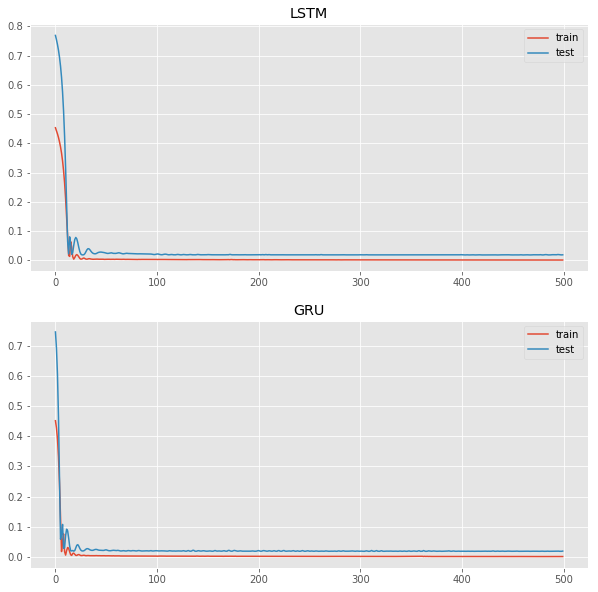

```
LSTM RMSE: 39.2673862029551
GRU RMSE: 39.455165507225885
```

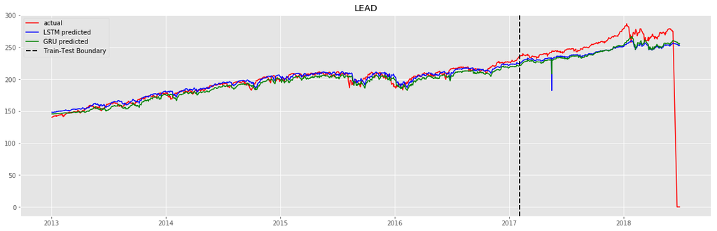

```
403.28609419617766
```

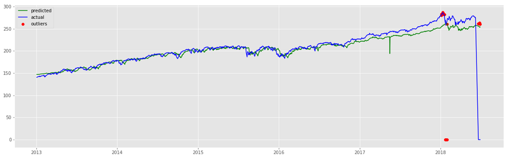

```python
#current best
'''
neurons = [264, 264, 264, 264]
dropouts = [0.1, 0.1, 0.1]
activation = ['relu', 'relu', 'relu', 'relu']
epochs = 200
batchsize = 50
'''

neurons = [264, 264, 264]
dropouts = [0.3, 0.3]
activation = ['relu', 'relu', 'relu']
epochs = 500
batchsize = 1000
name = 'lead_10'
res0, ensemble_resultdf, lstm, gru, test_X, test_y, score_frame = start_driver(name, lead_10, lead_10_scaled, values, scaled,
                                                                               epochs_=epochs, batchsize=batchsize, neurons=neurons,
                                                                               dropouts=dropouts, activations=activation)
```

#### Model Reliability Matrix

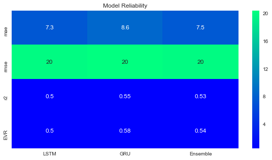

```python
  #appraises : winter_r, Spectral, summer_r,
  sns.set(rc={'figure.figsize':(10,5)})
  sns.heatmap(score_frame, annot=True, cmap='winter')
  plt.title('Model Reliability')
  plt.show()
```

### HighCharts

```python
H, x, data = highchartPred('Lead 10', res0, df, ensemble_resultdf)
# need javascript to run in browser
HTML(x)
```

Loading....

```python
#Can run without javascript
H
```

[interactive chart not shown]

```python
m, k = uncertain_high(lstm, 'lead 10', test_X, test_y, data, percent=75)
# need javascript to run in browser
HTML(k)
```

```
0.153934662423345
```

Loading....

##### Uncertainity

Assigning a percentage.  
Predicts the upper limit and lower limit of our prediction within range error

```python
#Can run without javascript
m
```

[interactive chart not shown]

### To-Dos:

- Fine tune models
- Predict for more at once
- Multi-thread Pipeline.